# Parameterized single cellline vs control

````r
```r
exp.cellLine <- params$experimentalCellLine
cont.cellLine <- params$controlCellLine
dds.subset <- params$dds.subset
rm(params) # remove parameters so we can test individual parts of the RStudio environment without Errors
````

[output not shown]

## Differential expression analysis

Run Deseq on the data set.

```r
# Saving time by just loading the dds we already ran (recent changes are all after this point)
load(str_interp("Rdata/${exp}_vs_${cont}_dds.RData"))
```

### Print DESeq2 results

```r
res <- results(dds.pair, contrast = c("CellLine", exp, cont), alpha = 0.05)
res <- res[order(res$log2FoldChange), ]
outFile <- str_interp("output/${exp}_vs_${cont}_deseq_results.csv")
write.csv(as.data.frame(res), file = outFile)
```

### Filter DESeq2 results for significant genes

Filter res for padj < 0.05

```r
res.filtered <- as.data.frame(res) %>%
  filter(padj < 0.05)
  # filter(log2FoldChange >= 1.5 | log2FoldChange <= -1.5)
res.filtered <- res.filtered[order(res.filtered$log2FoldChange, decreasing = TRUE),]
res.filtered
```

#### Significant “Up” genes (OVCAR4B compared to control OVCAR4)

```r
up.unfiltered <- subset(res, log2FoldChange > 0)
up.unfiltered <- up.unfiltered[order(up.unfiltered$log2FoldChange, decreasing = TRUE), ]
outFile <- str_interp("output/${exp}_vs_${cont}_all_upregulated_genes.csv")
write.csv(up.unfiltered[, c("log2FoldChange", "padj")], file = outFile)
up.unfiltered[, c("log2FoldChange", "padj")]

up <- subset(res.filtered, log2FoldChange > 0)
up <- up[order(up$log2FoldChange, decreasing = TRUE), ]
outFile <- str_interp("output/${exp}_vs_${cont}_significantly_upregulated_genes.csv")
write.csv(up[, c("log2FoldChange", "padj")], file = outFile)
print(up[, c("log2FoldChange", "padj")])
```

#### Significant “Down” genes (OVCAR4B compared to control OVCAR4)

```r
down.unfiltered <- subset(res, log2FoldChange < 0)
down.unfiltered <- down.unfiltered[order(down.unfiltered$log2FoldChange, decreasing = FALSE), ]
outFile <- str_interp("output/${exp}_vs_${cont}_all_downregulated_genes.csv")
write.csv(down.unfiltered[, c("log2FoldChange", "padj")], file = outFile)
print(down.unfiltered[, c("log2FoldChange", "padj")])

down <- subset(res.filtered, log2FoldChange < 0)
down <- down[order(down$log2FoldChange, decreasing = TRUE), ]
outFile <- str_interp("output/${exp}_vs_${cont}_significantly_downregulated_genes.csv")
write.csv(down[, c("log2FoldChange", "padj")], file = outFile)
print(down[, c("log2FoldChange", "padj")])
```

### Volcano Plot

```r
as.data.frame(res) %>%
  ggplot(aes(x = log2FoldChange, y = -log10(padj), label = rownames(res))) +
  geom_point() +
  theme_minimal() +
  scale_color_manual(values = c("black", "blue", "red")) +
  geom_text_repel() +
  geom_hline(yintercept = 1.301) +
  geom_vline(xintercept = 1.2) +
  geom_vline(xintercept = -1.2) +
  xlim(-10, 10)
```

[output not shown]

## Gene Ontology

### GSEA of genes differentially express in (OVCAR4B compared to control OVCAR4)

Perform gene set enrichment analysis using Cluster Profiler. This gives us GO pathways that are significantly regulated based on the log2fold change of expression of individual genes.

Using a pvalue Cutoff of 0.05

```r
gene_list <- res$log2FoldChange
names(gene_list) <- rownames(res)
gene_list <- sort(gene_list, decreasing = TRUE)

# Set the seed so our results are reproducible:
set.seed(2023)
gsea_res <- gseGO(gene_list, ont = "BP", OrgDb = "org.Hs.eg.db", keyType = "SYMBOL", seed = TRUE, pvalueCutoff = 0.05)

# Format output
gsea_res_df <- as.data.frame(gsea_res)
gsea_res_df <- gsea_res_df %>%
  mutate(original_row_num = row_number())
gsea_res_df <- gsea_res_df[order(gsea_res_df$NES, decreasing = TRUE),]
row.names(gsea_res_df) <- gsea_res_df$ID
```

NES is the normalized enrichment score.

```r
gsea_res_df_short <- gsea_res_df[c("pvalue", "p.adjust", "NES", "Description")]
gsea_res_df_short$"core_enrichment_genes" <- gsea_res_df$core_enrichment
```

#### Upregulated pathways

```r
gsea_res_df_short.up <- subset(gsea_res_df_short, gsea_res_df_short$NES >= 0)
outFile <- str_interp("output/${exp}_vs_${cont}_significantly_upregulated_pathways.csv")
write.csv(gsea_res_df_short.up, file = outFile)
gsea_res_df_short.up
```

GSEA plot of the five most upregulated pathways (or least downregulated)

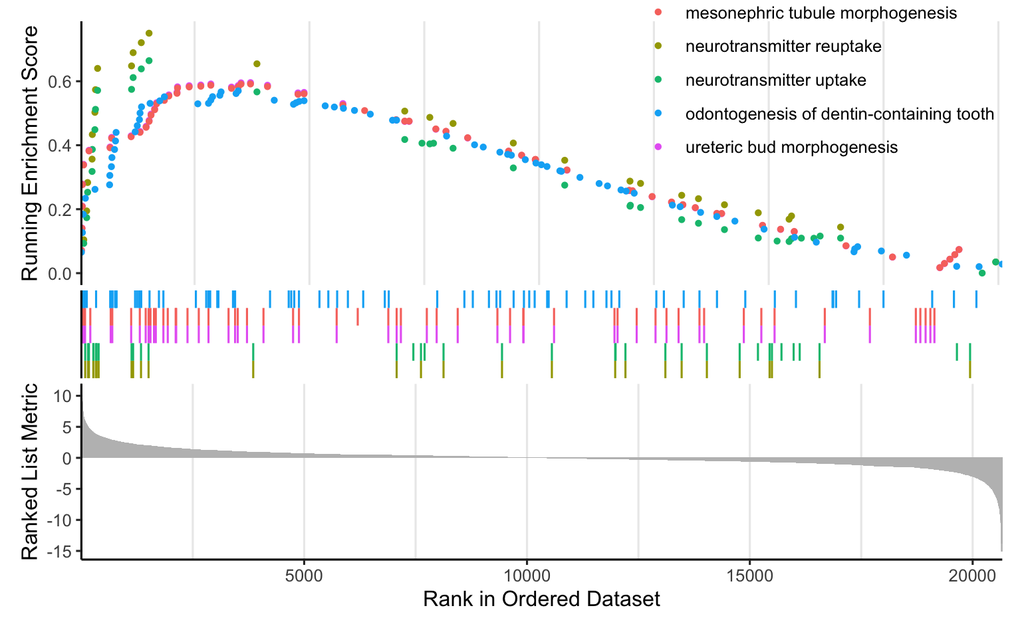

```r
maxIndex <- min(5, nrow(gsea_res_df)) # Prevents us from trying to access out of bounds if there are not five pathways
top5PathwaysIds = gsea_res_df[1:maxIndex, "original_row_num"]

gseaplot2(gsea_res, geneSetID = top5PathwaysIds, pvalue_table = FALSE, ES_geom = "dot")
```

Volcano Plot (Average NES & adjusted p value)

```r
as.data.frame(gsea_res_df_short.up) %>%
  ggplot(aes(x = NES, y = -log10(p.adjust), label = rownames(gsea_res_df_short.up))) +
  geom_point() +
  theme_minimal() +
  scale_color_manual(values = c("black", "blue", "red")) +
  geom_text_repel() +
  geom_hline(yintercept = 1.301) +
  geom_vline(xintercept = 1.2) +
  geom_vline(xintercept = -1.2) +
  xlim(-10, 10)
```

[output not shown]

#### Downregulated pathways

```r
gsea_res_df_short.down <- subset(gsea_res_df_short, gsea_res_df_short$NES <= 0)
outFile <- str_interp("output/${exp}_vs_${cont}_significantly_downregulated_pathways.csv")
write.csv(gsea_res_df_short.down, file = outFile)
gsea_res_df_short.down
```

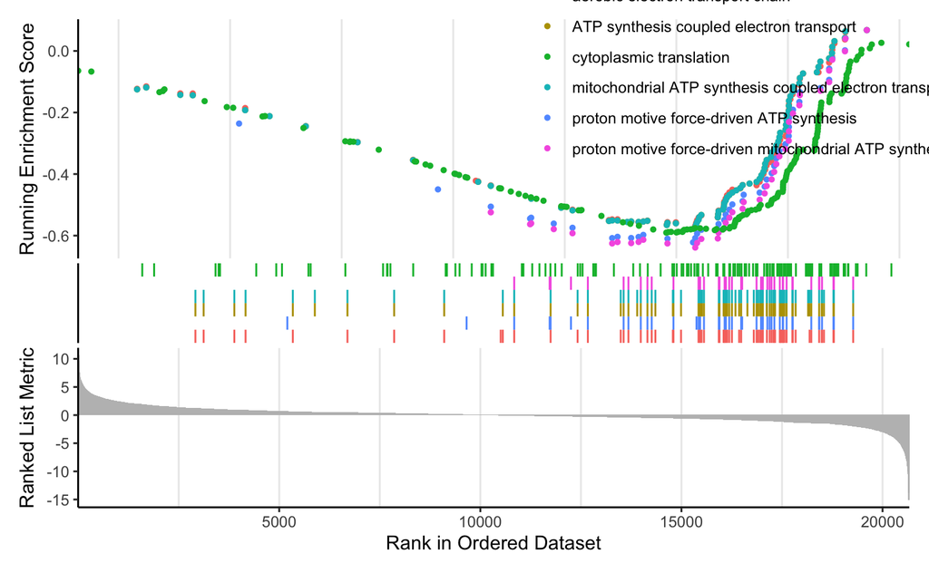

```r
minIndex <- max(1, nrow(gsea_res_df) - 5) # Prevents us from trying to access out of bounds if there are not five downregulated pathways
bottom5PathwaysIds = gsea_res_df[minIndex:nrow(gsea_res_df), "original_row_num"]
gseaplot2(gsea_res, geneSetID = bottom5PathwaysIds, pvalue_table = FALSE, ES_geom = "dot")
```

Volcano plot (Average NES & adjusted p value)

```r
as.data.frame(gsea_res_df_short.down) %>%
  ggplot(aes(x = NES, y = -log10(p.adjust), label = rownames(gsea_res_df_short.down))) +
  geom_point() +
  theme_minimal() +
  scale_color_manual(values = c("black", "blue", "red")) +
  geom_text_repel() +
  geom_hline(yintercept = 1.301) +
  geom_vline(xintercept = 1.2) +
  geom_vline(xintercept = -1.2) +
  xlim(-10, 10)
```

[output not shown]

### Clustered pathways

#### Clustered upregulated pathways

Use Revigo to cluster upregulated pathways

```r
revigo_input.cellline.up <- gsea_res_df_short.up[c("p.adjust")]
rownames(revigo_input.cellline.up) <- rownames(gsea_res_df_short.up)

simMatrix <- calculateSimMatrix(rownames(revigo_input.cellline.up),
  orgdb = "org.Hs.eg.db",
  ont = "BP",
  method = "Rel"
)
scores <- setNames(-log10(revigo_input.cellline.up$p.adjust), rownames(revigo_input.cellline.up))

if (nrow(revigo_input.cellline.up) > 1) {
  reducedTerms <- reduceSimMatrix(simMatrix,
    scores,
    threshold = 0.7,
    orgdb = "org.Hs.eg.db"
  )
} else {
  reducedTerms <- data.frame(matrix(ncol = 0, nrow = 0))
  print("There will be no graphs appearing below this because there were not enough significantly upregulated pathways to meaningfully cluster them")
}
```

Revigo interactive scatter plot. Distances represent the similarity between terms, axes are the first 2 components of a PCA plot, Each bubble indicates the representative (chosen mostly by p-value) from a cluster of terms. Size of the bubble indicates the generality of the term (large meaning a more general term).

```r
if (nrow(reducedTerms) > 2) {
  revigo_scatterplot(simMatrix, reducedTerms)
}
```

Revigo heatmap plot. Similar terms clustered

```r
if (nrow(reducedTerms) > 2) {
  heatmapPlot(simMatrix,
    reducedTerms,
    annotateParent = TRUE,
    annotationLabel = "parentTerm",
    fontsize = 6
  )
}
```

This is the same content, but interactive.

```r
if (nrow(reducedTerms) > 2) {
  revigo_heatmap(simMatrix, reducedTerms)
}
```

Revigo treemap plot. Terms grouped/colored based on parent. Space is proportional to statistical significance of the GO term (-log10(pvalue)).

```r
if (nrow(reducedTerms) > 2) {
  treemapPlot(reducedTerms)
}
```

#### Clustered downregulated pathways

Use Revigo to cluster downregulated pathways

```r
revigo_input.cellline.down <- gsea_res_df_short.down[c("p.adjust")]
rownames(revigo_input.cellline.down) <- rownames(gsea_res_df_short.down)

simMatrix <- calculateSimMatrix(rownames(revigo_input.cellline.down),
  orgdb = "org.Hs.eg.db",
  ont = "BP",
  method = "Rel"
)

scores <- setNames(-log10(revigo_input.cellline.down$p.adjust), rownames(revigo_input.cellline.down))

if (nrow(revigo_input.cellline.down) > 1) {
  reducedTerms <- reduceSimMatrix(simMatrix,
    scores,
    threshold = 0.7,
    orgdb = "org.Hs.eg.db"
  )
} else {
  reducedTerms <- data.frame(matrix(ncol = 0, nrow = 0))
  print("There will be no graphs appearing below this because there were not enough significantly downregulated pathways to meaningfully cluster them")
}
```

Revigo interactive scatter plot. Distances represent the similarity between terms, axes are the first 2 components of a PCA plot, Each bubble indicates the representative (chosen mostly by p-value) from a cluster of terms. Size of the bubble indicates the generality of the term (large meaning a more general term).

```r
if (nrow(reducedTerms) > 2) {
  revigo_scatterplot(simMatrix, reducedTerms)
}
```

Revigo heatmap plot. Similar terms clustered

```r
if (nrow(reducedTerms) > 2) {
  heatmapPlot(simMatrix,
    reducedTerms,
    annotateParent = TRUE,
    annotationLabel = "parentTerm",
    fontsize = 6
  )
}
```

This is the same content, but interactive.

```r
if (nrow(reducedTerms) > 2) {
  revigo_heatmap(simMatrix, reducedTerms)
}
```

Revigo treemap plot. Terms grouped/colored based on parent. Space is proportional to statistical significance of the GO term (-log10(pvalue)).

```r
if (nrow(reducedTerms) > 2) {
  treemapPlot(reducedTerms)
}
```